# Chapter 9 Coding Set

**Remember to save a copy of this template BEFORE YOU START WORKING :)**

Work completed by Isaiah Garrison.

If you start to struggle with a problem for an extended period of time, remember you can go comment on two other submissions now (seeing other student work helps), or you can post in our discussion forum for questions, which can also earn you extra credit.

## Imports

**If your program requires additional modules, external resources, or files, use this cell to set them up**

```python
# configure your environment

# you can uncomment this code to make use of files stored in your Google Drive
# from google.colab import drive
# drive.mount('/content/drive')

# you can uncomment the following line of code to use the pandas library
# import pandas as pd
```

## Programming Exercises

### Problem 1

#### Question Text

Write a program that creates a dictionary containing course numbers and the room numbers of the rooms where the courses meet. The dictionary should have the following keyvalue pairs:

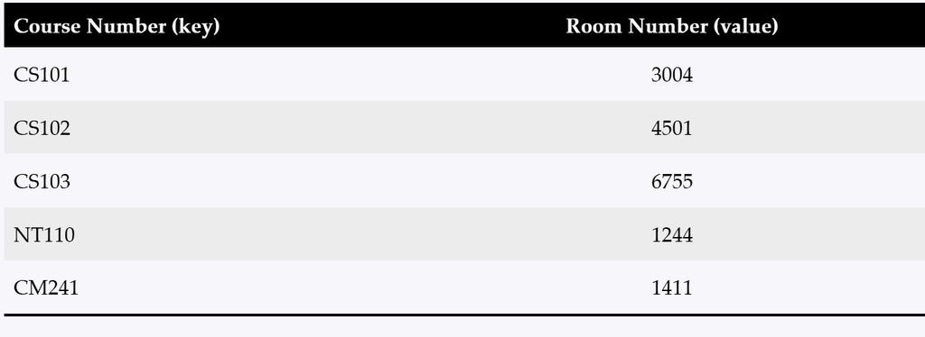

The program should also create a dictionary containing course numbers and the names of the instructors that teach each course. The dictionary should have the following key-value pairs:

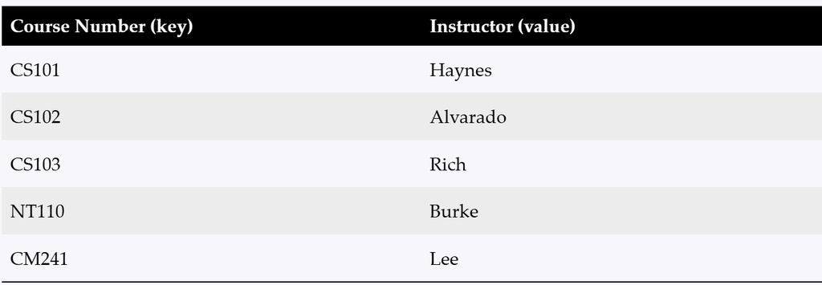

The program should also create a dictionary containing course numbers and the meeting times of each course. The dictionary should have the following key-value pairs:

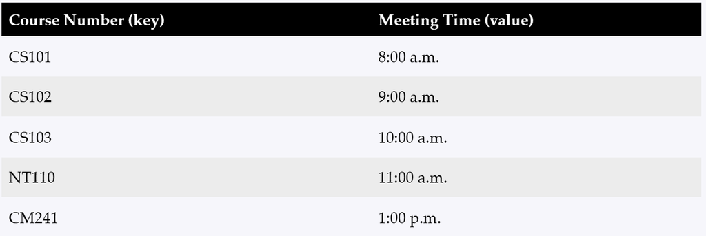

The program should let the user enter a course number, then it should display the course’s room number, instructor, and meeting time.

#### High-Level Overview

Going into this, I was first thinking about how I was going to lay the function out. I didn't know if I should start with lists or use loops. I just went ahead and make the dictionaries and stopped overcomplicating it. After that, I knew I could use "get" to retrive values from keys but forgot it doesn't display it. Overall, I think I did pretty good and not too bad.

[figure not shown]

```python
# add your code to this cell
# remember to include comments like this one for most of your code
# remember to "Run cell" once you're done, excecuting your code so the output is displayed below

# Making the main function
def main(user_number):
    # creating the rooms dictionary
    rooms_dict = {"CS101":3004, "CS102":4501, "CS103":6755, "NT110":1244, "CM241":1411}
    # creating the instructors dictionary
    instructors_dict = {"CS101":"Haynes", "CS102":"Alvarado", "CS103":"Rich", "NT110":"Burke", "CM241":"Lee"}
    # creating the meeting times dictionary
    meetingtimes_dict = {"CS101":"8:00 a.m.", "CS102":"9:00 a.m.", "CS103":"10:00 a.m.", "NT110":"11:00 a.m.", "CM241":"12:00 p.m."}
    # displaying the attached rooms
    user_room = rooms_dict.get(user_number)
    print(f"Your attached room number is {user_room}")
    # displaying the attached instructors
    user_instuctor = instructors_dict.get(user_number)
    print(f"Your attached instructor is {user_instuctor}")
    # displaying the attached meeting times
    user_meettimes = meetingtimes_dict.get(user_number)
    print(f"Your attached meeting time is {user_meettimes}")

# running the function
if __name__ == "__main__":
    # asking user for course number
    user_number = input("Please enter a course number")
    main(user_number)
```

```
Your attached room number is 4501
Your attached instructor is Alvarado
Your attached meeting time is 9:00 a.m.
```

## Helpful Checks

1. Did you comment every line of code with meaningful information that will help others reading your code?
2. Did you use appropriate names for your variables, functions, and/or classes?
3. Did you include a high-level explanation for each solution?
4. Did you run each cell that includes a final solution so the output is saved and easily viewed by others?
5. Are you sharing an editable link (i.e., Share > Anyone with the link > Editor) if using Colaboratory, or did you make more than ten commits if using GitHub?
6. Did you remember to comment on the submissions of two other students?